# Copilot Consumption and Ways of Working

[figure not shown]

[figure not shown]

[figure not shown]

[figure not shown]

[figure not shown]

[figure not shown]

[figure not shown]

[figure not shown]

[figure not shown]

[figure not shown]

[figure not shown]

# Overview

Synthetic demonstration Simulated values in real export schemas: a weekly Person query, daily Microsoft 365 credit consumption by service, daily GitHub AI credits, GitHub Copilot activity metrics, GitHub feature/model/language breakdowns, and Consumption metadata. The analysis first aggregates product feeds to a single Person × week panel, then uses that joined panel to compare observed product mix with Ways of Working outcomes. Empty panels and NA values denote withholding or undefined rates, not zero.

### People represented

480

### Observed M365 enabled population

85.4%

### M365 credits per person per week

946.4

### Observed GitHub population

38.3%

### Consumption baselines by function

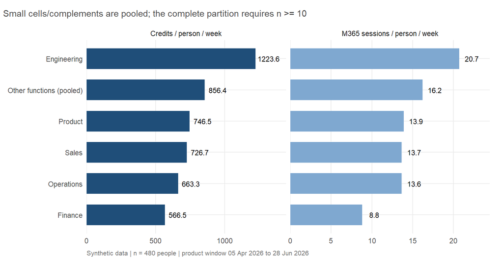

### Baseline table

Function baseline; unsafe contributor/complement cells are pooled before release. Credits per session uses observed Microsoft 365 sessions, not tokens.

| Function | People | M365 credits / person / week | M365 sessions / person / week | M365 credits / session |
| --- | --- | --- | --- | --- |
| Engineering | 206 | 1223.6 | 20.7 | 59.03 |
| Other functions (pooled) | 75 | 856.4 | 16.2 | 52.86 |
| Product | 72 | 746.5 | 13.9 | 53.72 |
| Sales | 44 | 726.7 | 13.7 | 53.21 |
| Operations | 54 | 663.3 | 13.6 | 48.63 |
| Finance | 29 | 566.5 | 8.8 | 64.35 |

### Population-level highlights

**Product mix is the new baseline.** The report now separates observed M365 Copilot and GitHub Copilot activity before relating either product to working patterns. M365 credits, GitHub AI credits and GitHub activity remain separate measures; no common unit or conversion has been confirmed.

**Consumption is concentrated.** Across the observed product window, the highest-volume 10% of people with positive Microsoft 365 credits account for 38.0% of all observed M365 credits. Concentration is reported within each product separately: M365 credits and GitHub AI credits are different units and are never pooled into a shared denominator. See the consumption detail page for the concentration cuts and the heavy-user pattern split.

**Enablement is a people measure.** M365 enablement is reported as the share of people with any observed enabled day, not as a percentage of possible enabled days.

**Ways of Working comparisons use the joined product window.** The Person query has 26 weeks of collaboration history, while product feeds cover 13 weeks of weekday daily records. Relationships in this report use the product weeks after aggregating all product files to a single Person × week panel.

### How to read cost intensity

**M365 credits per session** is retained as an appendix-style intensity measure. It is not a productivity or value measure, and it does not establish that a group is more or less efficient.

# Product usage mix

### Observed product mix

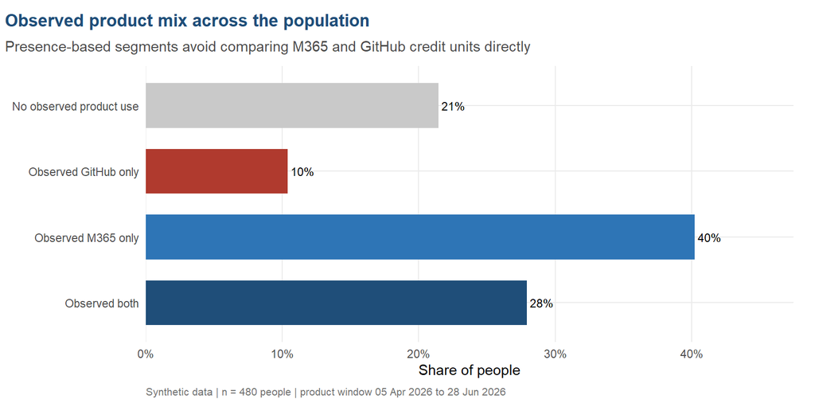

### Product-mix baseline

Observed product mix from the joined person-week panel. No observed product use is not proof of non-use.

| Segment | People | Share of population | M365 enabled users | M365 credits / person / week | GitHub credits / person / week | GitHub active days / person |
| --- | --- | --- | --- | --- | --- | --- |
| Observed both | 134 | 28% | 100% | 1656.0 | 72.5 | 43.1 |
| Observed M365 only | 193 | 40% | 100% | 1203.9 | 0.0 | 0.0 |
| Observed GitHub only | 50 | 10% | 66% | 0.0 | 89.1 | 44.4 |
| No observed product use | 103 | 21% | 49% | 0.0 | 0.0 | 0.0 |

### M365 credit volume within observed product mix

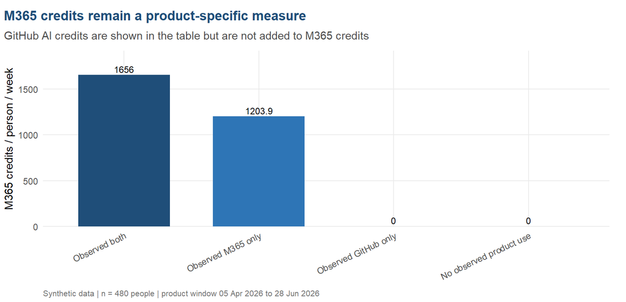

### Join strategy

The dashboard first aggregates every daily or dimensional product export to `PersonId × MetricDate`, where `MetricDate` is the Sunday week start. The joined panel then has one row per Person Query row, so downstream charts cannot accidentally multiply people by service, feature, language or model dimensions.

# Collaboration load

### Collaboration volume by observed product mix

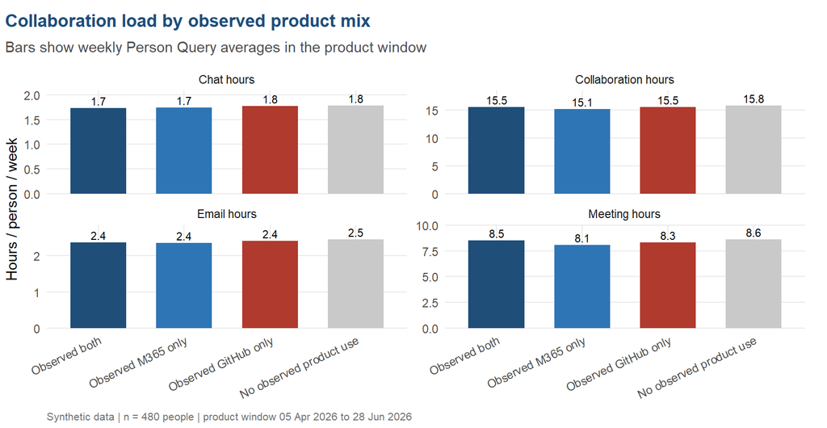

### Collaboration mode mix

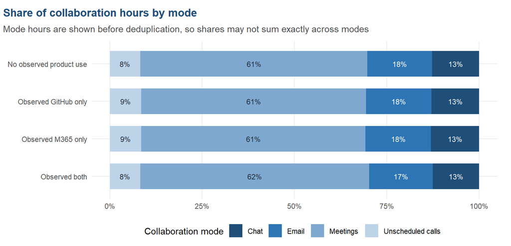

# Network breadth

### Network size by observed product mix

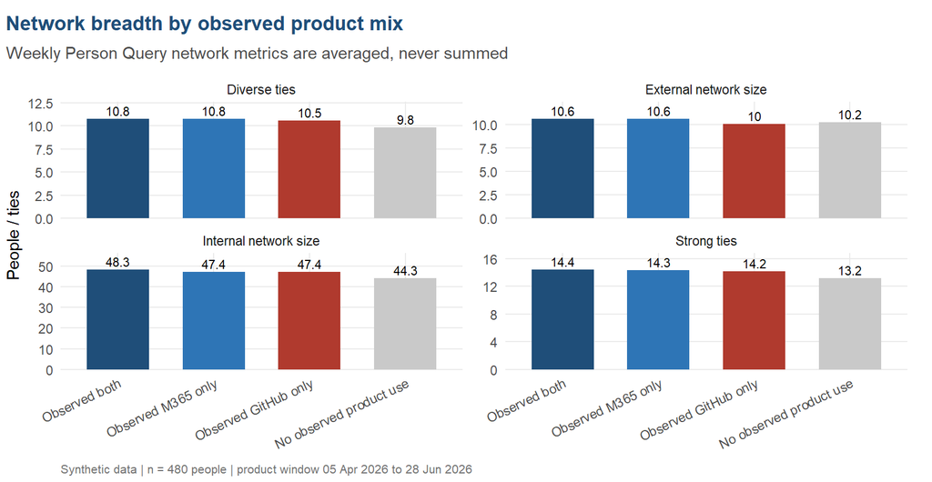

### Reading the network measures

Network metrics describe collaboration breadth in the observed calendar and communication graph. They do not measure relationship quality, influence, delivery quality or business impact. The useful question is whether product-use segments have visibly different collaboration reach that deserves deeper analysis.

### M365 credit volume and network

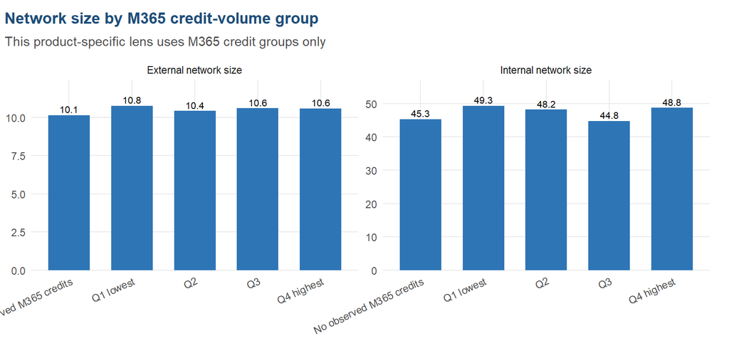

# After-hours working

### After-hours and weekend collaboration by product mix

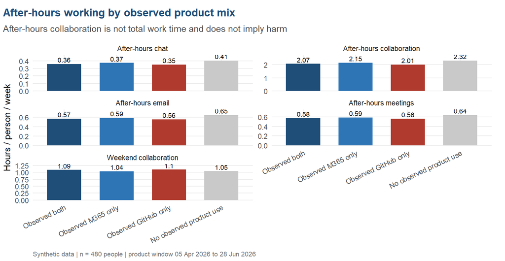

### Interpretation guardrail

After-hours collaboration counts meetings, email, Teams chats, calls and channels with at least one other person outside configured working hours, with overlapping activity deduplicated. It is not total work time. Flexible schedules, on-call duties and time zones may matter, but none is recorded here.

### M365 cost intensity and workload

```
Profile partition withheld: one or more cells or complements are below the publication floor.
```

# Appendix: consumption detail

### Credit concentration

Share of each product’s observed credits used by its highest-volume people, ranked within that product. Percentiles are taken among people with positive observed credits. A share is withheld unless both the top group and the remaining population meet the publication floor. M365 and GitHub credits are separate units and are never added.

| Product | People with positive credits | Share used by top 10% | Share used by top 25% |
| --- | --- | --- | --- |
| Microsoft 365 Copilot credits | 327 | 38.0% | 61.2% |
| GitHub AI credits | 184 | 38.5% | 60.0% |

### Heavy-user consumption pattern

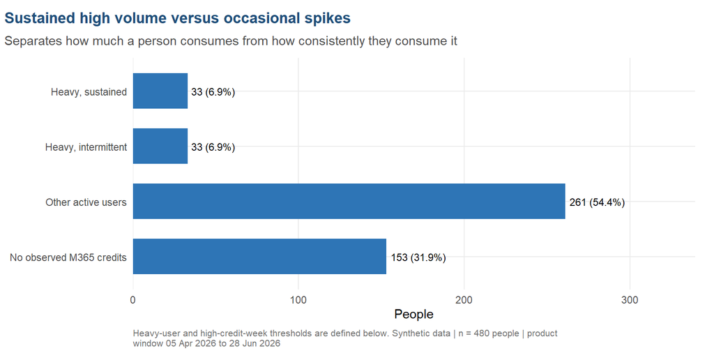

### Reading the intensity measures

**Volume and consistency answer different questions.** Concentration shows how much of the observed credit total sits with the highest-volume people. The pattern split shows whether those people consume at that level habitually or in occasional bursts. A group can be concentrated without being habitual.

**The window is 13 product weeks.** Consistency is measured inside that window only. It is a lookback description, not a trend, and it cannot show whether a pattern is starting or fading. Unobserved weeks are excluded from both the threshold and the per-person counts, so a coverage gap is never counted as a quiet week.

**Thresholds are parameters, not findings.** Heavy user: top 20% of people with positive observed M365 credits, by average weekly credits. High-credit week: a person-week at or above the 90th percentile of all active person-weeks. Sustained: at least 50% of a person’s observed weeks are high-credit weeks. Changing any threshold changes the groups; narrower heavy-user cuts are permitted and will be withheld whenever a resulting group falls below the publication floor.

### Service mix

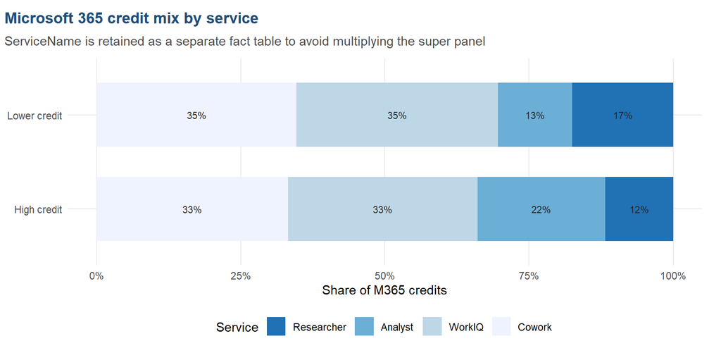

### M365 credit-volume groups

M365 credit-volume groups. Quartiles are calculated among people with positive observed M365 credits; people with no observed M365 credits are retained separately.

| CreditQuartile | People | Credits / person / week | M365 credits / session | Share of population |
| --- | --- | --- | --- | --- |
| No observed M365 credits | 153 | 0.0 | N/A | 31.9% |
| Q1 lowest | 82 | 311.2 | 30.45 | 17.1% |
| Q2 | 82 | 679.3 | 39.02 | 17.1% |
| Q3 | 82 | 1177.3 | 47.98 | 17.1% |
| Q4 highest | 81 | 3413.8 | 72.75 | 16.9% |

### Cost-intensity profile availability

```
Profile partition withheld: one or more cost-intensity cells or complements are below the publication floor.
```

### Profile definitions

| Profile component | Definition | Interpretation |
| --- | --- | --- |
| High credit | Upper quartile of average weekly M365 credits among positive M365 users | Higher M365 credit volume |
| Lower credit | Other positive M365 users | Lower M365 credit volume |
| High cost per session | Upper quartile of M365 credits per session among people with at least 10 observed M365 sessions | More credits used per observed M365 session |
| Standard cost per session | Below the high-cost threshold, with enough observed sessions | Lower observed M365 cost intensity |
| Limited M365 sessions | Fewer than 10 observed M365 sessions, including zero-session and GitHub-only people | Insufficient sessions; never included in standard/high-cost comparisons |

The label **high cost per session** describes a measurable consumption pattern. It is not a wellbeing, productivity or value judgement.

### Profile baseline

```
Profile baseline withheld: the complete ConsumptionProfile by CreditQuartile partition does not meet the publication floor.
```

# Methods and appendix

### Join and aggregation workflow

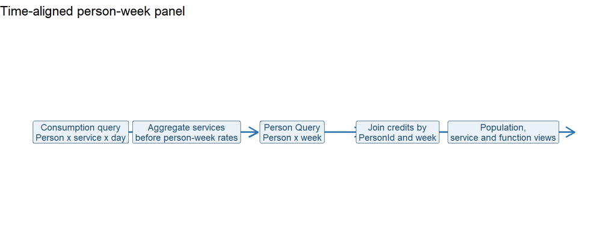

### Core rules

[output not shown]

### Key crosswalk check

Crosswalk diagnostics are qualitative: no small exception counts or reconstructible crosswalk totals are published.

| Check | Status |
| --- | --- |
| PeopleMetaData people with no activity-file crosswalk | Review required |
| Credit activity rows with PeopleHistoricalId absent from PeopleMetaData | Pass |

### Simulation design

This dashboard is a demonstration of analytical possibilities. Every person, credit, session and Ways of Working value is synthetic.

The current source set represents 480 synthetic people. The person query spans 26 Sunday-start weeks. The M365 and GitHub credit feeds cover the final 13 weeks at weekday daily grain, which is why this report filters Ways of Working measures to the product window before relating them to credits.

Available-to-focus hours are simulated on a 40-hour weekly basis here, but that basis is configurable per tenant through metric rules. The metric describes calendar time left after meetings and scheduled Teams calls, and should not be read as coding time or psychological flow.

The following effects are deliberately modest:

- Higher consumption is associated with more chat and less email as a share of collaboration modes.
- Total collaboration volume is raised mainly by organisational composition.
- Internal network size has a small residual association after composition is considered.
- Cost per M365 session has a weak association with after-hours collaboration in some credit bands.
- External network size is a null.

### Synthetic source assets

The uncompressed source-shaped CSVs sit under:

```
examples/utility-r/_data/
  person-query/PersonQuery.csv
  consumption-query/PeopleMetaData.csv
  consumption-query/PersonM365CreditsMetrics.csv
  consumption-query/PersonGitHubCreditsMetrics.csv
```

They are intended for demonstrations, workshops and adaptation of the template. They contain no customer data or real identifiers. The GitHub-query files in the same folder are not required for this consumption report.

### Definitions and limitations

**Credits per session** means Microsoft 365 Copilot credits consumed divided by observed Microsoft 365 Consumption-query sessions. It is preferred over any token-normalised measure because token fields are not present in this export.

**Available-to-focus hours** means working hours remaining after excluding meetings and scheduled Teams calls. `Uninterrupted_hours` and `Interrupted_hours` partition available-to-focus time in this source. The working-hours basis is tenant-configurable; the 40-hour identity checked here is specific to this synthetic dataset.

**Credit activity segments** are based on active product weeks and observed M365 credit volume. They are not the standard `vivainsights` action-based segments, because this source set does not include a Copilot actions metric.

**PeopleHistoricalId** is the documented join key between the Consumption activity files and `PeopleMetaData`. It must be taken from the Consumption export rather than derived from `PersonId`. A person-query export alone cannot be joined to `PeopleMetaData`; the bridge is an activity file that carries both `PersonId` and `PeopleHistoricalId`.

The dashboard shows associations. It does not establish that AI consumption caused a working pattern, and it does not observe output quality, task difficulty or business value. It also makes no wellbeing claims: uninterrupted, interrupted, available-to-focus, after-hours and weekend measures describe observed calendar and collaboration patterns only.

### Replacing the synthetic data

1. Replace the four CSVs listed above with schema-aligned governed exports.
2. Validate the identity crosswalk and disclose the match rate.
3. Require independent, week-relevant eligibility and ingestion/coverage evidence before zero filling. Missing rows alone do not establish zero activity or no provisioning; M365 enabled days do not establish GitHub provisioning. Missing person-weeks remain unknown here. Recorded sums per analysis week are lower bounds when completeness is unknown, not complete-period consumption.
4. Preserve the daily service grain until after service-level totals are needed; aggregate services before computing person-week rates.
5. Keep person-level averaging so each person carries equal analytical weight.
6. Retain the minimum of 10 and whole-partition disclosure gates, including contributor complements and shared gates for related tables/charts. Blank charts, empty tables and NA values mean withheld (or undefined rates), not zero. Overlapping releases require a governed cross-report disclosure review; these within-report checks are not a certification of arbitrary real data.
7. Keep M365 Copilot credits and GitHub AI credits in separate panels and denominators unless an authoritative common-unit/conversion contract is established.